# VRA Section 2 Analysis-Congressional Districts

DRAFT–Internal Use Only

5/28/2021

Initial Analysis of VRA Section 2 assessment is to check the race/ethnicity of the current district to get a baseline of minority VAP/CVAP from 2010. If the minority population hasn’t decreased, then we need to at least keep the same number of minority opportunity districts as last time.

**Steps**

1. Get race/eth summary by congressional district from 2010.
2. Compare race/eth summary from 2010 to race/eth summary from most recent estimates (2019 ACS) to review population changes.
3. Determine how many minority opportunity districts you can create where the race/ethnicity share is 50%+.

## Step 1: Identify 2010 Minority Opportunity Districts

Which current Congressional Districts had 50% or more of the Citizen Voting Age Population (CVAP) in 2010?

### Latinx

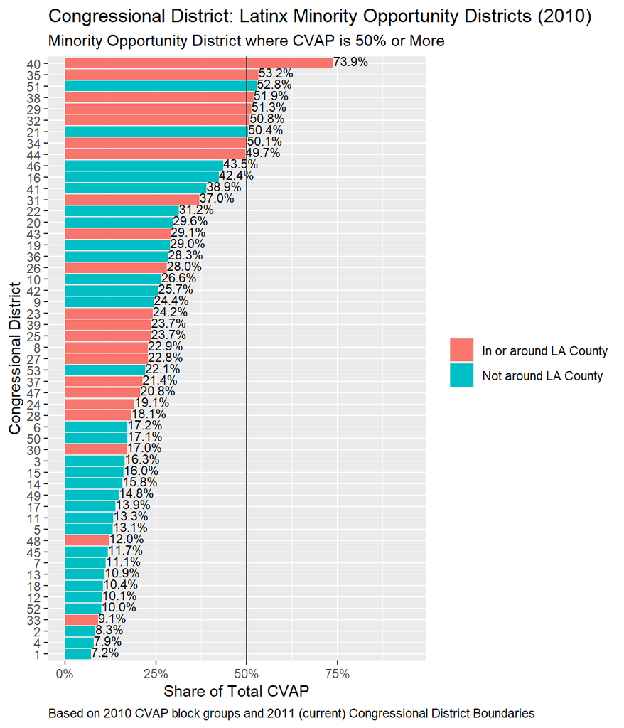

- Of Congressional districts in/around LA County, 40 (SELA-Huntington Park), 35 (Pomona-Orange County), 38 (SELA-Whittier), 29 (SFV), 32 (SGV East) and 34 (Koreatown, East LA) had a Latinx CVAP share exceeding 50% in 2010.

### Black

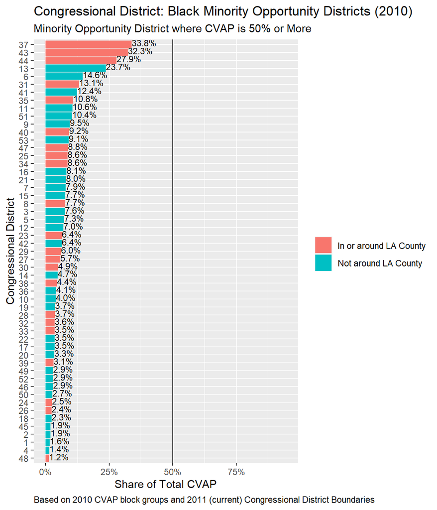

- Of Congressional districts in/around LA County, none had majority Black CVAP in 2010. Districts 37 (South/Central/West LA), 43 (Inglewood/South Bay) and 44 (Compton/South Bay East) had the highest share in the state (around 28-33% CVAP).

### Asian

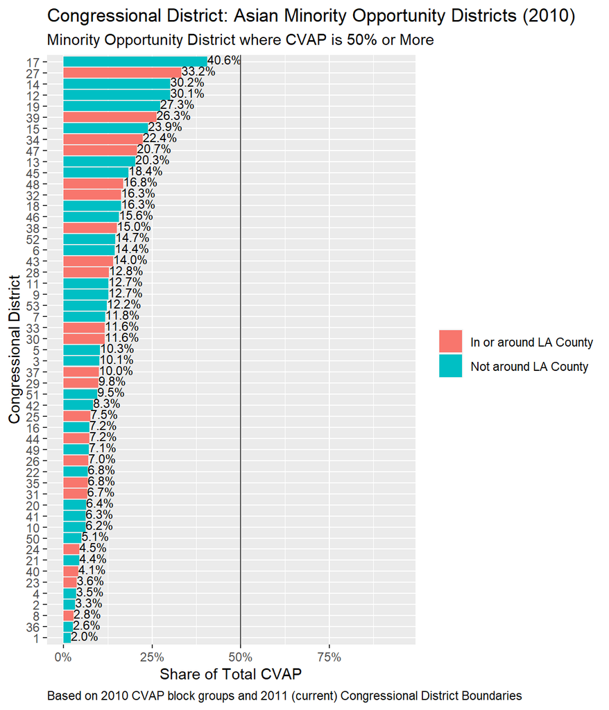

- Of Congressional districts in/around LA County, none had majority Asian CVAP in 2010. District 27 (Pasadena) had the highest share in the county (33%), followed by District 39 (SGV-Orange County).

## Step 2: Identify Population Changes from 2011

### How has the Citizen Voting Age Population Changed?

#### Latinx CVAP Changes

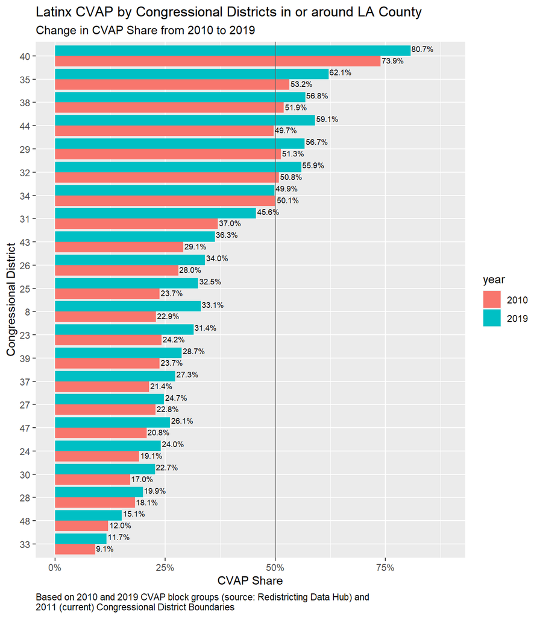

- In the districts where the Latinx CVAP share exceeded 50% in 2010, the Latinx CVAP share has increased substantially over the past ten years (with the exception of District 34, which remained about the same).
- Districts 35 (Pomona-Orange County) and 44 (Compton-South Bay) have had about a 10 percentage point increase in Latinx CVAP.

#### Black CVAP Changes

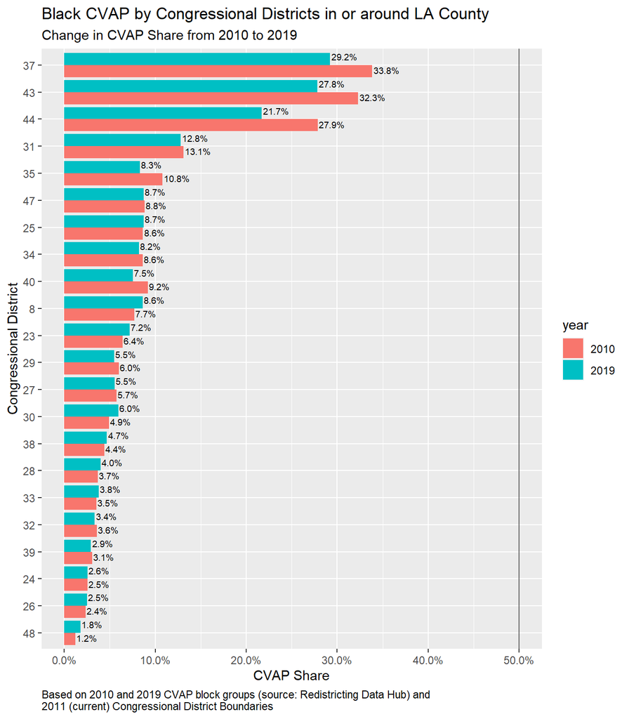

- Congressional districts in and around LA County have had an overall decrease or steady maintenance in Black CVAP.
- There are a few districts with small increases in Black CVAP (e.g. District 8 (San Bernardino County), 23 (Lancaster-Kern County), 30 (SFV-Canoga Park-Sherman Oaks)), but are not close to having majority of the total CVAP.

#### Asian CVAP Changes

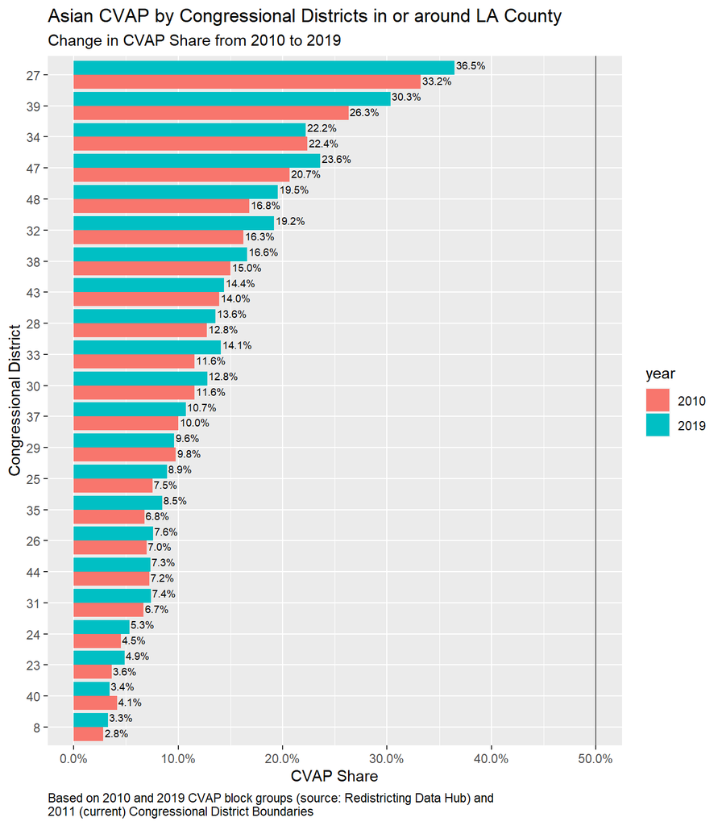

- Congressional districts in and around LA County have had an overall increase or steady maintenance in Asian CVAP.
- Districts 27 (Pasadena) and 39 (SGV-Orange County) have had substantial Asian CVAP increases, but are not close to having the majority.

## Step 3: Given the current CVAP, how many minority opportunity districts can be created?

TBD…

#### What is the ideal total population per district?

- [US Census Bureau apportionment population](https://www.census.gov/data/tables/2020/dec/2020-apportionment-data.html) is 39,576,757, and 52 districts have been allocated to California.
- Dividing the state population by 52 districts means the ideal district population is 761,091.

## Current Congressional District Map for Districts In and Around LA County

For reference: click on the map to see the district number.

[interactive chart not shown]

## Sources/References:

- (LA County Legal Considerations)[https://www.google.com/url?sa=t&rct=j&q=&esrc=s&source=web&cd=&cad=rja&uact=8&ved=2ahUKEwiYmdHxyO3wAhXFl54KHRJoDi8QFjAAegQIBRAD&url=http%3A%2F%2Ffile.lacounty.gov%2FSDSInter%2Fbos%2Fsupdocs%2F59570.pdf&usg=AOvVaw103KyrNp2M6LKrGwQNCION]
- (Public Mapping)[http://www.publicmapping.org/what-is-redistricting/redistricting-criteria-the-voting-rights-act]